# 信风 - 船价预测模型

```r
library(RJSONIO)
library(ggplot2)
library(grid)
library(gridExtra)
library(dplyr)
library(readxl)
library(readr)
library(reshape)
library(zoo)
library(glmnet)
```

数据已经清理完毕，整合在了同一个dataframe里。但我们在这个时候只关心出现频次最高的港口和船只类型。由于“船只类型”为类型变量，有可能有些船只只在某一次竞标内出现，所以没法再训练集中被拟合。我们在筛选出数据中班次最多的五个港口和三种船只类型： - 镇海，海兆，江甬， 椒江，黄埔 - 0.5万吨，1.3-1.5万吨，1-1.25万吨 每次以单次竞标的班次作为测试集，其他竞标班次作为训练集，做交叉检验。

## 1. 导入数据

```r
remove(list = ls())
load("regress_df.Rda")
regress.df <- filter(regress.df, port %in% c('NingBoZhenHai', 'NingBoHaiZhao', 'NingBoJiangYong', 'JiaoJiangSSZD', 'NingBoHuaPu'),vsl_type %in% c('0.5W', '1.3-1.5W', '1-1.25W'))
regress.df
```

| bid_time | cost | adjusted_cost | ship_year | ship_month | ship_month_factor | ship_month_square | trend | port | total_weight | vsl_type | contract_time | ship_time | DaysFromBid | BDI | BDI_month_diff_perc | BDI_2wk_diff_perc | BDI_1wk_diff_perc | BDI_month_diff | BDI_2wk_diff | BDI_1wk_diff | CNB_Idx | CNB_Idx_month_diff_perc | CNB_Idx_month_diff | Fuel180 | Fuel180_month_diff_perc | Fuel180_2wk_diff_perc | Fuel180_1wk_diff_perc | Fuel180_month_diff | Fuel180_2wk_diff | … |
| --- | --- | --- | --- | --- | --- | --- | --- | --- | --- | --- | --- | --- | --- | --- | --- | --- | --- | --- | --- | --- | --- | --- | --- | --- | --- | --- | --- | --- | --- | --- |
| 2016-05-12 | 50.00 | 45.00 | 2016 | 5 | 5 | 25 | 5 | NingBoHaiZhao | 1883.841 | 0.5W | 2016-05-15 | 2016-05-20 | 8 days | 579 | 0.03392857 | -0.184507042 | -0.098130841 | 19 | -131 | -63 | 7613.875 | 0.006367527 | 48.1748 | 244.5 | 0.164285714 | 0.063043478 | 0.03382664 | 34.5 | 14.5 | … |
| 2016-05-12 | 43.00 | 38.00 | 2016 | 5 | 5 | 25 | 5 | NingBoHaiZhao | 2380.966 | 0.5W | 2016-05-21 | 2016-05-26 | 14 days | 579 | 0.03392857 | -0.184507042 | -0.098130841 | 19 | -131 | -63 | 7613.875 | 0.006367527 | 48.1748 | 244.5 | 0.164285714 | 0.063043478 | 0.03382664 | 34.5 | 14.5 | … |
| 2016-05-12 | 43.00 | 38.00 | 2016 | 5 | 5 | 25 | 5 | NingBoHuaPu | 74.680 | 0.5W | 2016-05-21 | 2016-05-26 | 14 days | 579 | 0.03392857 | -0.184507042 | -0.098130841 | 19 | -131 | -63 | 7613.875 | 0.006367527 | 48.1748 | 244.5 | 0.164285714 | 0.063043478 | 0.03382664 | 34.5 | 14.5 | … |
| 2016-05-12 | 43.00 | 38.00 | 2016 | 5 | 5 | 25 | 5 | NingBoJiangYong | 1649.380 | 0.5W | 2016-05-21 | 2016-05-26 | 14 days | 579 | 0.03392857 | -0.184507042 | -0.098130841 | 19 | -131 | -63 | 7613.875 | 0.006367527 | 48.1748 | 244.5 | 0.164285714 | 0.063043478 | 0.03382664 | 34.5 | 14.5 | … |
| 2016-05-12 | 47.00 | 42.00 | 2016 | 5 | 5 | 25 | 5 | JiaoJiangSSZD | 5016.340 | 0.5W | 2016-05-25 | 2016-05-30 | 18 days | 579 | 0.03392857 | -0.184507042 | -0.098130841 | 19 | -131 | -63 | 7613.875 | 0.006367527 | 48.1748 | 244.5 | 0.164285714 | 0.063043478 | 0.03382664 | 34.5 | 14.5 | … |
| 2016-05-12 | 27.00 | 27.00 | 2016 | 6 | 6 | 36 | 6 | NingBoZhenHai | 12462.276 | 1.3-1.5W | 2016-05-27 | 2016-06-01 | 20 days | 579 | 0.03392857 | -0.184507042 | -0.098130841 | 19 | -131 | -63 | 7613.875 | 0.006367527 | 48.1748 | 244.5 | 0.164285714 | 0.063043478 | 0.03382664 | 34.5 | 14.5 | … |
| 2016-05-12 | 43.00 | 38.00 | 2016 | 6 | 6 | 36 | 6 | NingBoHaiZhao | 4707.230 | 0.5W | 2016-06-01 | 2016-06-06 | 25 days | 579 | 0.03392857 | -0.184507042 | -0.098130841 | 19 | -131 | -63 | 7613.875 | 0.006367527 | 48.1748 | 244.5 | 0.164285714 | 0.063043478 | 0.03382664 | 34.5 | 14.5 | … |
| 2016-05-12 | 43.00 | 38.00 | 2016 | 6 | 6 | 36 | 6 | NingBoHaiZhao | 4443.818 | 0.5W | 2016-06-01 | 2016-06-06 | 25 days | 579 | 0.03392857 | -0.184507042 | -0.098130841 | 19 | -131 | -63 | 7613.875 | 0.006367527 | 48.1748 | 244.5 | 0.164285714 | 0.063043478 | 0.03382664 | 34.5 | 14.5 | … |
| 2016-05-12 | 44.00 | 39.00 | 2016 | 6 | 6 | 36 | 6 | NingBoHaiZhao | 2248.100 | 0.5W | 2016-06-01 | 2016-06-06 | 25 days | 579 | 0.03392857 | -0.184507042 | -0.098130841 | 19 | -131 | -63 | 7613.875 | 0.006367527 | 48.1748 | 244.5 | 0.164285714 | 0.063043478 | 0.03382664 | 34.5 | 14.5 | … |
| 2016-05-12 | 44.00 | 39.00 | 2016 | 6 | 6 | 36 | 6 | NingBoJiangYong | 77.990 | 0.5W | 2016-06-01 | 2016-06-06 | 25 days | 579 | 0.03392857 | -0.184507042 | -0.098130841 | 19 | -131 | -63 | 7613.875 | 0.006367527 | 48.1748 | 244.5 | 0.164285714 | 0.063043478 | 0.03382664 | 34.5 | 14.5 | … |

[output cut: 430 more lines]

## 2. 基准模型（简单的回归模型，不含指数信息）

基准模型为

$$\text{Cost} \sim~ \text{Long-term Trend} + \text{Month} + \text{Month}^2 + \text{Vsl_Type} + \text{Port}$$
其中

- Long-term Trend = 船期当月到2016年“0月”的月份数, 例如. 2016年一月对应数值为1, 2017年2月对应数值为14.\
- Month - 月份，数值变量，1，2，3，…， 12
- Month$^2$ - 月份的平方，数值变量，用来拟合年份内U形或者倒U型的趋势
- Vsl_Type - 类别变量
- Port - 类别变量

对于每个模型我们比较其一下统计量 （“平均”指的是对每个交叉检测的测试集结果取平均）

- 平均 $R^2$
- 平均 MAE
- 平均 MAPE
- 平均竞标总价误差（Total Bid Cost-Absolute Error, TBC-AE)：档次实际竞标总价（只包含五大港口和三种主要船型）和主要船型（三中）和对该次竞标预测的总价之间误差的绝对值，单位为万元。 TBC—CE不包括绑垫、跨港、逾期、理货等费用
- 平均竞标总价误差（Total Bid Cost-Absolute Percentage Error, TBC-APE）: TBC-AE/总价

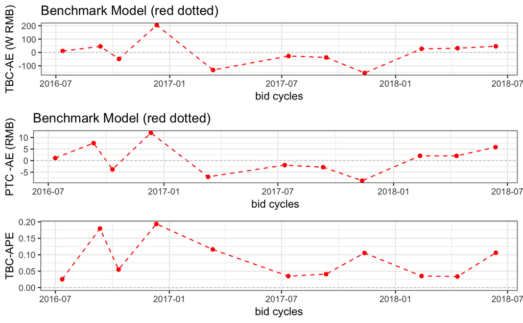

```r
r_square_list_1 <- c()
mae_list_1 <- c()
mape_list_1 <- c()
total_cost_err_list_1 <- c()
total_cost_perc_list_1 <- c()
unit_cost_err_list_1 <- c()
bid_cycles <- unique(regress.df$bid_time)[-1]
for (bid in bid_cycles){
  train.df <- filter(regress.df, bid_time != bid)
  test.df <- filter(regress.df, bid_time == bid)
  model <- lm(cost ~ trend + ship_month + ship_month_square + vsl_type + port, data = train.df)

  result_test_raw <- data.frame(true = test.df$cost, pred = predict(model, test.df),
                                wgt = test.df$total_weight)
  result_test_raw$error <- result_test_raw$true - result_test_raw$pred
  r_square <- summary(model)$r.squared
  r_square_list_1 <- c(r_square_list_1, r_square)
  mae <- mean(abs(result_test_raw$error))
  mae_list_1 <-c(mae_list_1, mae)
  mape <- mean(abs(result_test_raw$error) / result_test_raw$true)
  mape_list_1 <- c(mape_list_1, mape)

  actual_total_cost = sum(result_test_raw$true * result_test_raw$wgt)
  pred_total_cost = sum(result_test_raw$pred * result_test_raw$wgt)
  total_cost_err = (pred_total_cost - actual_total_cost)/10000
  unit_cost_err =  total_cost_err*10000/sum(result_test_raw$wgt)
  total_cost_err_perc = (pred_total_cost - actual_total_cost)/actual_total_cost

  total_cost_err_list_1 <- c(total_cost_err_list_1, total_cost_err)
  total_cost_perc_list_1 <- c(total_cost_perc_list_1, total_cost_err_perc)
  unit_cost_err_list_1 <- c(unit_cost_err_list_1, unit_cost_err)

}
res_1 <- c(mean(r_square_list_1), mean(mae_list_1), mean(mape_list_1),
           mean(abs(total_cost_err_list_1)), mean(abs(total_cost_perc_list_1)), mean(abs(unit_cost_err_list_1)))
temp1 <- data.frame(bid_cycles = bid_cycles, total_cost_error = total_cost_err_list_1, total_cost_error_perc = total_cost_perc_list_1,
                    unit_cost_error = unit_cost_err_list_1)
#

g.top <- ggplot(data = temp1, aes(x = bid_cycles, y = total_cost_error)) +
  theme_bw() + geom_line(linetype = "dashed", color = "red") + geom_point(color = "red") +
  geom_hline(yintercept = 0, linetype = "dotted", color = "grey") +
  labs(x = "bid cycles", title = "Benchmark Model (red dotted)", y = "TBC-AE (W RMB)")

g.mid <- ggplot(data = temp1, aes(x = bid_cycles, y = unit_cost_error)) +
  theme_bw() + geom_line(linetype = "dashed", color = "red") + geom_point(color = "red") +
  geom_hline(yintercept = 0, linetype = "dotted", color = "grey") +
  labs(x = "bid cycles", title = "Benchmark Model (red dotted)", y = "PTC -AE (RMB)")
g.bottom<- ggplot(data = temp1, aes(x = bid_cycles, y = abs(total_cost_error_perc))) +
  theme_bw() + geom_line(linetype = "dashed", color = "red") + geom_point(color = "red") +
  geom_hline(yintercept = 0, linetype = "dotted", color = "grey") +
  labs(x = "bid cycles", y = "TBC-APE")
epsilon = 0.05
mat <- matrix(c(1,2,3), nrow = 3)
grid.arrange(g.top, g.mid, g.bottom, nrow = 3)
```

以上第一张图解释了每次竞标的总成本的absolute erroe (AE), 第二张图解释了每次竞标平均每吨成本AE，第三张图解释了每次竞标的absolute percentage erroe (APE)。 基准模型的平均$R^2$大概为79%, 不过整体的预测效果还是差强人意（正值代表高估了整体价格， 负值代表低估了整体船价）。 以下表格是各项指标的平均值。

```r
res_1 <- data.frame(Benchmark_Model = res_1)
rownames(res_1) = c("R-square", "MAE", "MAPE", "TBC-AE", "TBC-APE", "PTC-AE")
res_1
```

|  | Benchmark_Model |
| --- | --- |
| R-square | 0.79004159 |
| MAE | 7.20638937 |
| MAPE | 0.12372517 |
| TBC-AE | 69.33299318 |
| TBC-APE | 0.08416441 |
| PTC-AE | 4.99997153 |

## 3. 包含指数信息的回归模型

我们收集并清理了一下指数：

- BDI (波罗的海指数，来源：李博石月月收集)
- CNB_Idx (中国沿海杂散货航运指数，来源：彭博客户端)
- Fuel180 (180号船用燃油香港期货交易现货价格，来源：彭博客户端)
- SH_GP_Price (上海钢坯价格，来源：李博石月月收集)
- SH_LWG_Price (上海螺纹钢价格，来源：李博石月月收集)
- Shanghang_Idx (上航指数，来源：李博石月月收集)
- SHCB_Idx (上海航运交易所煤炭散货运输指数，来源：彭博客户端， 另外还有中国煤炭杂散货指数，同来自于彭博客户端，但是跟上海航运交易所煤炭散货运输指数相关性非常强，故先不予考虑)
- N_ZhaPu_2_3_wt (北方-乍浦2-3万吨价格，来源：李博石月月收集。该数据提取自神海指数。由于神海指数中几子价格相关性很强，而神海指数本身为几个子价格的平均值，故只选取跟镇海最近的乍浦港)

### 3.1 中国煤炭散货运输指数 vs. 上海航运交易所煤炭散货运输指数

```r
CN <- read_excel("CN_Coastal_Bulk_Coal_Freight_Idx.xlsx")
```

```
-
/
```

```r
SH <- read_excel("SHSPCBCF.xlsx")
```

```
-
/
```

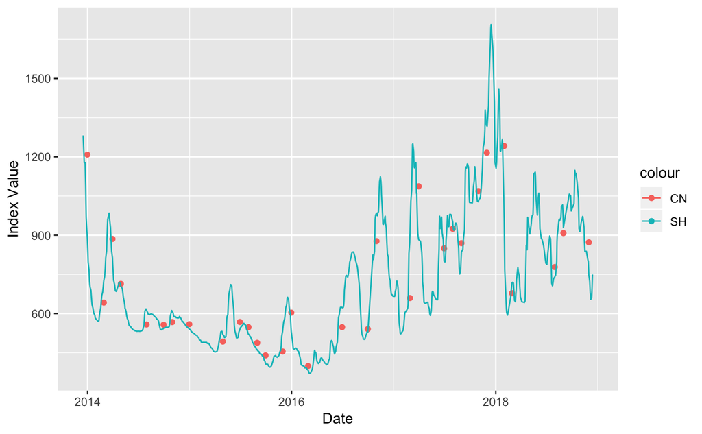

```r
CN <- rename(CN, c("China Coastal Bulk Coal Freight Index" = "CN_Coal_Idx"))
CN$Date <- as.Date(CN$Date, "%Y/%m/%d")
SH$Date <- as.Date(SH$Date, "%Y/%m/%d")
# c(min(SH$Date), max(SH$Date))
comparison = merge(x = CN, y = SH, by = "Date", all.y = TRUE)
ggplot(data = comparison, aes(x = Date)) +
  geom_point(aes(y = CN_Coal_Idx, color = "CN")) +
  geom_line(aes(y = SHSPCBCF, color = "SH")) +
  ylab("Index Value")
```

### 3.2 神海指数中各航线价格相关性

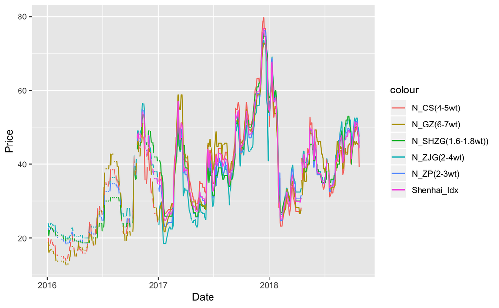

```r
# Shenhai Idx 2016
x <- read_excel("2016_ShenhaiIndex_Shi.xlsx")
x <- rename(x, c("date" = "Date",
                 "北-张家港（2-4万吨）" = "N_ZhangJiaGang_2_4wt",
                 "北-常熟（4-5万吨）" = "N_ChangShu_4_5_wt",
                 "北-乍浦（2-3万吨）" = "N_ZhaPu_2_3_wt",
                 "北-上海闸港（1.6-1.8万吨）" = "N_ShanghaiZhaGang_16_18_kt",
                 "北-广州（6-7万吨）" = "N_GuangZhou_6_7_wt",
                 "综合指数" = "Shenhai_Idx"))
x$Date <- as.Date(x$Date, "%Y/%m/%d")
ShenHai_Idx_2016 <- x
remove(x)
# Shenhai Idx 2017
x <- read_csv("2017_ShenhaiIndex_Shi.csv")
x <- rename(x, c("date" = "Date",
                 "北-张家港（2-4万吨）" = "N_ZhangJiaGang_2_4wt",
                 "北-常熟（4-5万吨）" = "N_ChangShu_4_5_wt",
                 "北-乍浦（2-3万吨）" = "N_ZhaPu_2_3_wt",
                 "北-上海闸港（1.6-1.8万吨）" = "N_ShanghaiZhaGang_16_18_kt",
                 "北-广州（6-7万吨）" = "N_GuangZhou_6_7_wt",
                 "综合指数" = "Shenhai_Idx"))
x$Date <- as.Date(x$Date, "%d/%m/%Y")
ShenHai_Idx_2017 <- x
remove(x)
# Shenhai Idx 2018
x <- read_csv("2018_ShenhaiIndex_Shi.csv")
x <- rename(x, c("日期" = "Date",
                 "北-张家港（2-3万吨）" = "N_ZhangJiaGang_2_4wt",
                 "北方-常熟（4-5万吨）" = "N_ChangShu_4_5_wt",
                 "北方-乍浦（2-3万吨）" = "N_ZhaPu_2_3_wt",
                 "北-上海闸港（1.6-1.8万吨）" = "N_ShanghaiZhaGang_16_18_kt",
                 "北方-广州（6-7万吨）" = "N_GuangZhou_6_7_wt",
                 "综合指数" = "Shenhai_Idx"))
x$Date <- as.Date(x$Date, "%Y/%m/%d")
ShenHai_Idx_2018 <- x
remove(x)
# Concatenate all years into a single file
x <- rbind(ShenHai_Idx_2016, ShenHai_Idx_2017, ShenHai_Idx_2018)
# Visualize all sub-price. It turns out they are pretty collinear
x$bm <- x$N_ZhangJiaGang_2_4wt
x$N_ChangShu_4_5_wt <- x$N_ChangShu_4_5_wt - mean(x$N_ChangShu_4_5_wt - x$bm, na.rm = TRUE)
x$N_ChangShu_4_5_wt <- x$N_ChangShu_4_5_wt - mean(x$N_ChangShu_4_5_wt - x$bm, na.rm = TRUE)
x$N_ZhaPu_2_3_wt <- x$N_ZhaPu_2_3_wt - mean(x$N_ZhaPu_2_3_wt - x$bm, na.rm = TRUE)
x$N_ShanghaiZhaGang_16_18_kt <- x$N_ShanghaiZhaGang_16_18_kt - mean(x$N_ShanghaiZhaGang_16_18_kt - x$bm, na.rm = TRUE)
x$N_GuangZhou_6_7_wt <- x$N_GuangZhou_6_7_wt - mean(x$N_GuangZhou_6_7_wt - x$bm, na.rm = TRUE)
ggplot(data = x, aes(x = Date)) +
  geom_line(aes(y = N_ZhangJiaGang_2_4wt, color = "N_ZJG(2-4wt)")) +
  geom_line(aes(y = N_ChangShu_4_5_wt, color = "N_CS(4-5wt)")) +
  geom_line(aes(y = N_ZhaPu_2_3_wt, color = "N_ZP(2-3wt)")) +
  geom_line(aes(y = N_ShanghaiZhaGang_16_18_kt, color = "N_SHZG(1.6-1.8wt))")) +
  geom_line(aes(y = N_GuangZhou_6_7_wt, color = "N_GZ(6-7wt)")) +
  geom_line(aes(y = Shenhai_Idx, color = "Shenhai_Idx")) +
  ylab("Price")
```

### 3.3 对指数的数据的处理

指数数据在录入时普遍存在几个问题:

1. 并不连续，有可能是每月一更新，有可能是周末更新
2. 起始点不同
3. 指数本身反应的是当日数值，而非预测值。故在及竞标当日`bid_time`我们无法知道签船日指数情况

故，对所有指数作如下处理：

- 创建一个 `Date` 轴，起始日为 2016-03-15，终止日为2018-8-15，涵盖每个自然日（不分周末）
- 若该日期指数值存在，取该值
- 若该日期指数值不存在，取之前最近一次非空数值

假设 $X(t)$ 为某指数，我们在数据库中加入如下差分变量和斜率变量

```
月，半月，周差分
X_month_diff(t) = X(t) - X(t - 30)
X_2wk_diff(t) = X(t) - X(t - 14)
X_1wk_diff(t) = X(t) - X(t - 7)

月，半月，周斜率
X_month_diff_perc(t) = (X(t) - X(t - 30)) / X(t - 30)
X_2wk_diff_perc(t) = (X(t) - X(t - 14)) / X(t - 14)
X_1wk_diff_perc(t) = (X(t) - X(t - 7)) / X(t - 7)
```

而对于每个船期`ship_time`，变量 `DaysFromBid` 表示该船期和竞标日之间的时间差，我们再加入船期当天对指数X的预测

```
月，半月，周预测
X_month_fcst(t) = X(bid_day) + X_month_diff(bid_day) * DaysFromBid / 30
X_2wk_fcst(t) = X(bid_day) + X_2wk_diff(bid_day) * DaysFromBid / 14
X_1wk_fcst(t) = X(bid_day) + X_1wk_diff(bid_day) * DaysFromBid / 7
```

注意，这里的`month_fcst`指的不是 t 之后一个月的预测，而是在 t 当日，用竞标日的指数值，利用其竞标日对应的月差分项然后做一个线性的预测。所以，所有的数据都是在竞标日当日及之前可以获得的，没有使用任何“超时空”的信息。

当然，我们新引入了很多变量，其结果就是有过多的变量需要我们做筛选。

### 3.4 带指数模型（Idx Model）

```r
bid_cycles <- unique(regress.df$bid_time)
last_bid <- tail(bid_cycles[bid_cycles < "2016-5-12"], 1)
# temp <- filter(regress.df, bid_time == last_bid)
# mean(temp$adjusted_cost)
length(last_bid)
```

```
[1] 0
```

加入变量“最近一次同类型船价”

```r
regress.df$price_diff <- regress.df$cost - regress.df$adjusted_cost
regress.df$latest_cost <- NA
regress.df$avg_latest_adj_cost <- NA
bid_cycles <- unique(regress.df$bid_time)
for (i in 1: nrow(regress.df)){
  temp = filter(regress.df, bid_time < regress.df[i, "bid_time"], price_diff == regress.df[i, "price_diff"],
                vsl_type == regress.df[i, "vsl_type"])
  if (nrow(temp) > 0) {
    regress.df[i, "latest_cost"] <- tail(temp$cost, 1)
  }
  else{
    temp = filter(regress.df, bid_time < regress.df[i, "bid_time"], vsl_type == regress.df[i, "vsl_type"])
    if (nrow(temp) > 0) {
    regress.df[i, "latest_cost"] <- tail(temp$adjusted_cost, 1) + regress.df[i, "price_diff"]
  }
  }

  last_bid <- tail(bid_cycles[bid_cycles < regress.df[i, "bid_time"]], 1)
  if (length(last_bid) > 0){
  temp2 <- filter(regress.df, bid_time == last_bid)
  regress.df[i, "avg_latest_adj_cost"] <- mean(temp2$adjusted_cost)
  }
}
regress.df$ship_year_factor <- as.factor(regress.df$ship_year)
```

*** ATT： 现有指数为手工挑选， 可以在现有基础上继续尝试

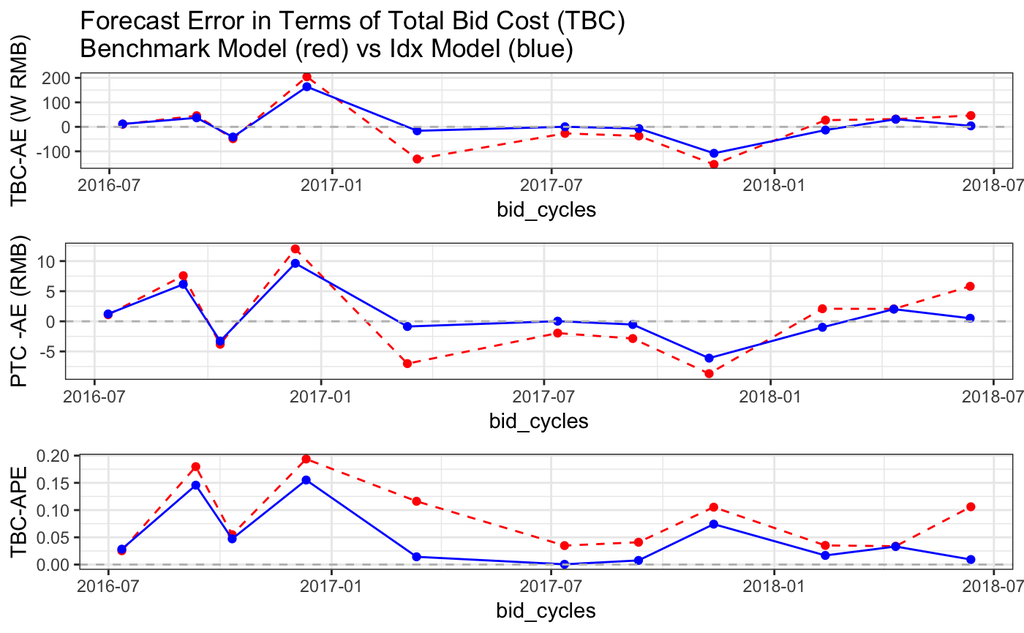

```r
r_square_list_2 <- c()
mae_list_2 <- c()
mape_list_2 <- c()
total_cost_list_2 <- c()
total_cost_perc_list_2 <- c()
unit_cost_err_list_2 <- c()
bid_cycles <- unique(regress.df$bid_time)[-1]
All_result <- data.frame(true = c(), pred = c(), wgt = c(), DaysFromBid = c(),
                         vsl_type = c(), bid_time = c(), ship_time = c())
regress.df$DaysFromBid <- as.numeric(regress.df$DaysFromBid)
regress.df$DaysFromBid_sq <- regress.df$DaysFromBid^2
for (bid in bid_cycles){
  train.df <- filter(regress.df, bid_time != bid)
  test.df <- filter(regress.df, bid_time == bid)
  # ================== Change Model Here ============================================
  model <- lm(cost ~ trend + ship_month + ship_month_square + vsl_type + port +
                Fuel180 +
                N_ZhaPu_2_3_wt_month_fcst, data = train.df)
  # =================================================================================

  result_test_raw <- data.frame(true = test.df$cost, pred = predict(model, test.df),
                                wgt = test.df$total_weight, DaysFromBid = test.df$DaysFromBid,
                                vsl_type = test.df$vsl_type, bid_time = test.df$bid_time,
                                ship_time = test.df$ship_time)

  All_result <- rbind(All_result, result_test_raw)

  result_test_raw$error <- result_test_raw$true - result_test_raw$pred
  r_square <- summary(model)$r.squared
  r_square_list_2 <- c(r_square_list_2, r_square)
  mae <- mean(abs(result_test_raw$error))
  mae_list_2 <-c(mae_list_2, mae)
  mape <- mean(abs(result_test_raw$error) / result_test_raw$true)
  mape_list_2 <- c(mape_list_2, mape)

  actual_total_cost = sum(result_test_raw$true * result_test_raw$wgt)
  pred_total_cost = sum(result_test_raw$pred * result_test_raw$wgt)
  total_cost_err = (pred_total_cost - actual_total_cost)/10000
  unit_cost_err =  total_cost_err*10000/sum(result_test_raw$wgt)
  total_cost_err_perc = (pred_total_cost - actual_total_cost)/actual_total_cost

  total_cost_list_2 <- c(total_cost_list_2, total_cost_err)
  total_cost_perc_list_2 <- c(total_cost_perc_list_2, total_cost_err_perc)
  unit_cost_err_list_2 <- c(unit_cost_err_list_2, unit_cost_err)


}
res_2 <- c(mean(r_square_list_2), mean(mae_list_2), mean(mape_list_2),
           mean(abs(total_cost_list_2)), mean(abs(total_cost_perc_list_2)), mean(abs(unit_cost_err_list_2)))
temp2 <- data.frame(bid_cycles = bid_cycles, total_cost_error2 = total_cost_list_2,
                    total_cost_error_perc2 = total_cost_perc_list_2, unit_cost_error2 = unit_cost_err_list_2)
comparison <- merge(temp1, temp2, by = "bid_cycles")
g.top <- ggplot(data = comparison, aes(x = bid_cycles)) +
  theme_bw() +
  geom_line(aes(y = total_cost_error), color = "red", linetype = "dashed") +
  geom_point(aes(y = total_cost_error), color = "red") +
  geom_line(aes(y = total_cost_error2), color = "blue") +
  geom_point(aes(y = total_cost_error2), color = "blue") +
  geom_hline(yintercept = 0, linetype = "dashed", color = "grey") +
  labs(title = "Forecast Error in Terms of Total Bid Cost (TBC)\nBenchmark Model (red) vs Idx Model (blue)", y = "TBC-AE (W RMB)")
g.mid <- ggplot(data = comparison, aes(x = bid_cycles)) +
  theme_bw() +
  geom_line(aes(y = (unit_cost_error)), color = "red", linetype = "dashed") +
  geom_point(aes(y = (unit_cost_error)), color = "red") +
  geom_line(aes(y = (unit_cost_error2)), color = "blue") +
  geom_point(aes(y = (unit_cost_error2)), color = "blue") +
  geom_hline(yintercept = 0, linetype = "dashed", color = "grey") +
  labs(y =  "PTC -AE (RMB)")
g.bottom <- ggplot(data = comparison, aes(x = bid_cycles)) +
  theme_bw() +
  geom_line(aes(y = abs(total_cost_error_perc)), color = "red", linetype = "dashed") +
  geom_point(aes(y = abs(total_cost_error_perc)), color = "red") +
  geom_line(aes(y = abs(total_cost_error_perc2)), color = "blue") +
  geom_point(aes(y = abs(total_cost_error_perc2)), color = "blue") +
  geom_hline(yintercept = 0, linetype = "dashed", color = "grey") +
  labs(y = "TBC-APE")
epsilon = 0.05
grid.arrange(g.top, g.mid, g.bottom, heights = c(0.5 + epsilon, 0.5, 0.5 - epsilon))
```

```r
comparison2 <- data.frame(Benchmark = res_1, IdxModel = res_2)
rownames(comparison2) <- c('Avg R Square', 'Avg Mae', 'Avg MAPE', 'TBC-AE', 'TBC-APE', 'PTC-AE')
comparison2
```

|  | Benchmark_Model | IdxModel |
| --- | --- | --- |
| Avg R Square | 0.79004159 | 0.81501365 |
| Avg Mae | 7.20638937 | 6.33984160 |
| Avg MAPE | 0.12372517 | 0.10863380 |
| TBC-AE | 69.33299318 | 39.41360978 |
| TBC-APE | 0.08416441 | 0.04835428 |
| PTC-AE | 4.99997153 | 2.84895230 |

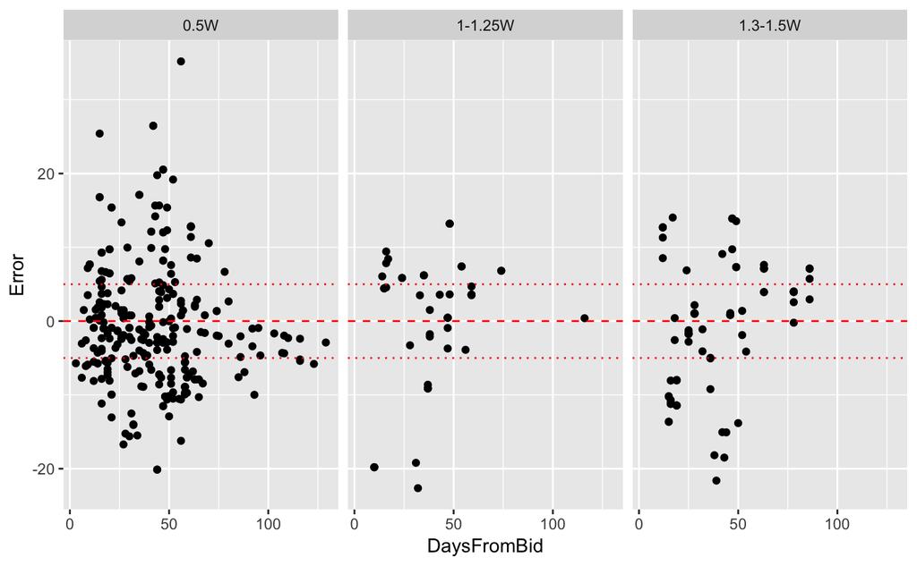

```r
All_result$Error <- All_result$true - All_result$pred
All_result$PercError <- (All_result$true - All_result$pred)/All_result$true
ggplot(data = All_result, aes(x = DaysFromBid)) +
  geom_point(aes(y = Error)) +
  geom_hline(yintercept = 0, linetype = "dashed", color = "red") +
  geom_hline(yintercept = 5, linetype = "dotted", color = "red") +
  geom_hline(yintercept = -5, linetype = "dotted", color = "red") +
  facet_wrap(~ vsl_type)
```

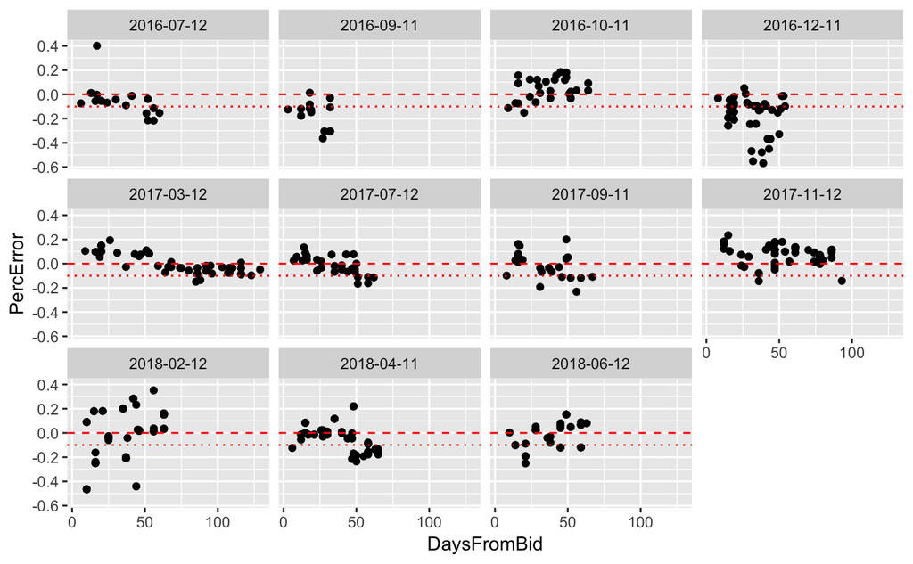

```r
ggplot(data = All_result, aes(x = DaysFromBid)) +
  geom_point(aes(y = PercError)) +
  geom_hline(yintercept = 0, linetype = "dashed", color = "red") +
  geom_hline(yintercept = -0.1, linetype = "dotted", color = "red") +
  geom_hline(yintercept = -0.1, linetype = "dotted", color = "red") +
  facet_wrap(~ bid_time)
```

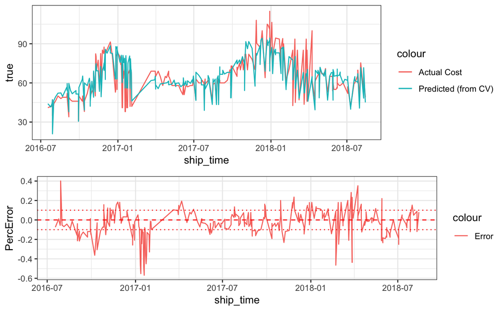

```r
g2.top <- ggplot(data = All_result, aes(x = ship_time)) +
  theme_bw() +
  geom_line(aes(y = true, color = "Actual Cost")) +
  geom_line(aes(y = pred, color = "Predicted (from CV)"))
g2.bottom <- ggplot(data = All_result, aes(x = ship_time)) +
  theme_bw() +
  geom_line(aes(y = PercError, color = "Error")) +
  geom_hline(yintercept = 0, linetype = "dashed", color = "red") +
  geom_hline(yintercept = 0.1, linetype = "dotted", color = "red") +
  geom_hline(yintercept = -0.1, linetype = "dotted", color = "red")
grid.arrange(g2.top, g2.bottom, heights = c(0.5 + epsilon, 0.5 - epsilon))
```